# Single Cell ATAC-seq of Mouse Brain Cells

# Machine Learning

```r
# pull cell type information
df_tsne_sub <- df_tsne_plot["type"]
row.names(df_tsne_sub) <- df_tsne_plot$barcode

# convert dataframe. sample barcode are rownames
df_tsne_ml <- df_tsne
rownames(df_tsne_ml) <- df_tsne_ml$barcode
df_tsne_ml <- merge(df_tsne_ml, df_tsne_sub, by=0)
rownames(df_tsne_ml) <- df_tsne_ml$barcode
df_tsne_ml <- df_tsne_ml[c("tSNE1", "tSNE2", "type")]
ML <- df_tsne_ml
```

### Split Data Into Training and Validation Sets

```r
# separate data into validation and training sets
library(caret)
validation_index <- createDataPartition(ML$type, p = 0.80, list = FALSE)

validation <- ML[-validation_index,]
ML <- ML[validation_index,]
```

### Training Set Data Exploration

```r
# view data
# dim(ML)
# sapply(ML, class)
# levels(ML$type)

# proportion of cell types
percentage <- prop.table(table(ML$type)) * 100
cbind(freq=table(ML$type), percentage=percentage)
```

```
##                   freq percentage
## astrocyte           56   8.358209
## excitatory_neuron  341  50.895522
## inhibitory_neuron  197  29.402985
## microglia           24   3.582090
## ODC_PDC             52   7.761194
```

```r
# summary(ML)
```

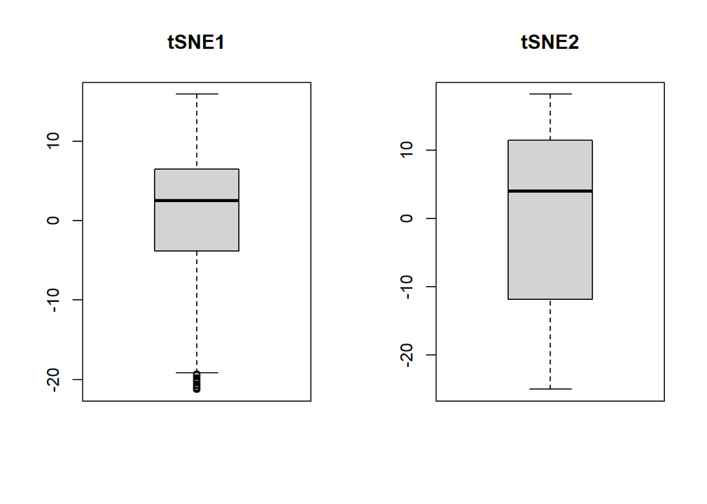

```r
# univariate plots
x <- ML[,1:2]
y <- ML[,3]

# variation over tsne1 and tsne2
par(mfrow=c(1,2))
for (i in 1:2) {
  boxplot(x[,i], main=names(ML)[i])
}
```

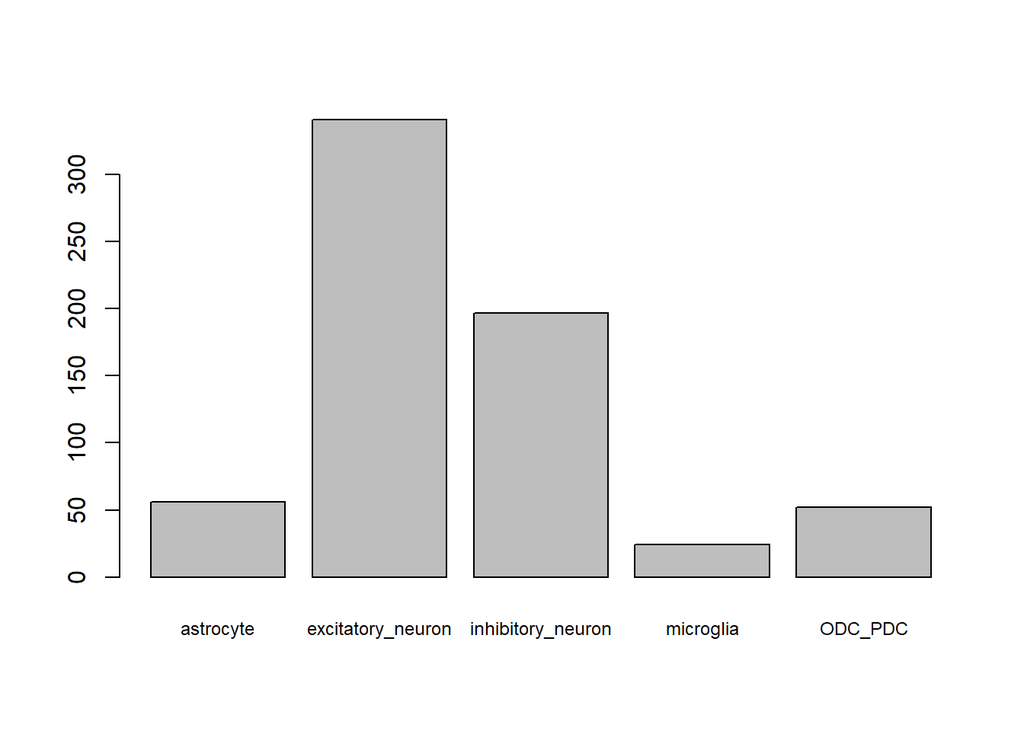

```r
# distribution of cell types
par(mfrow=c(1,1))
plot(y, cex.names=0.75)
```

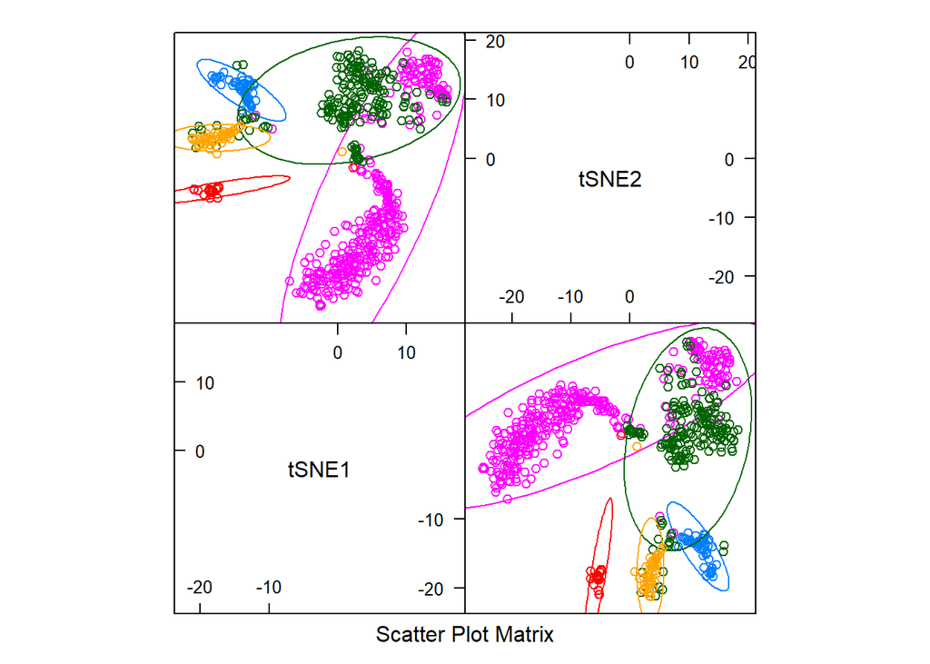

```r
library("ellipse")
# multivariate plots
featurePlot(x=x, y=y, plot="ellipse")
```

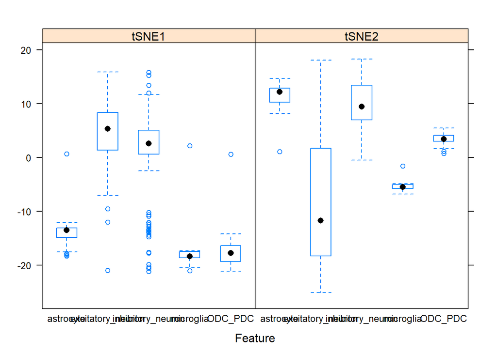

```r
featurePlot(x=x, y=y, plot="box")
```

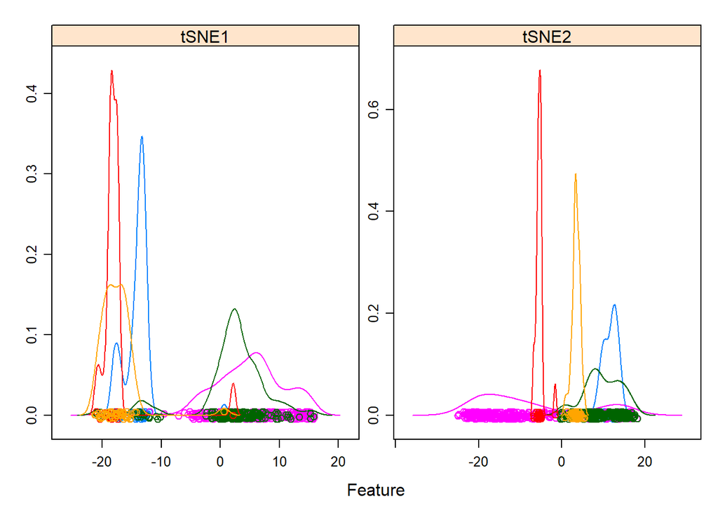

```r
# density plots, distributions of cell types over tsne1 and tsne2
scales <- list(x=list(relation="free"), y=list(relation="free"))
featurePlot(x=x, y=y, plot="density", scales=scales)
```

### Training Different Models

```r
control <- trainControl(method="cv", number = 10)
metric <- "Accuracy"

## the models

# linear discriminant analysis
set.seed(8)
fit.lda <- train(type~., data=ML, method="lda", metric=metric, trControl=control)

# classification and regressiontrees
set.seed(8)
fit.cart <- train(type~., data=ML, method="rpart", metric=metric, trControl=control)

# k-Nearest Neighbors (kNN)
set.seed(8)
fit.knn <- train(type~., data=ML, method="knn", metric=metric, trControl=control)

# Support Vector Machines with a linear kernel
set.seed(8)
fit.svm <- train(type~., data=ML, method="svmRadial", metric=metric, trControl=control)

# Random Forest
set.seed(8)
fit.rf <- train(type~., data=ML, method="rf", metric=metric, trControl=control)
# Summarize accuracy of models
results <- resamples(list(lda=fit.lda, cart=fit.cart, knn=fit.knn, svm=fit.svm, rf=fit.rf))
summary(results)
```

```
##
## Call:
## summary.resamples(object = results)
##
## Models: lda, cart, knn, svm, rf
## Number of resamples: 10
##
## Accuracy
##           Min.   1st Qu.    Median      Mean   3rd Qu.      Max. NA's
## lda  0.7462687 0.7670494 0.8496156 0.8319919 0.8690857 0.9420290    0
## cart 0.8769231 0.8962795 0.9083916 0.9058424 0.9219710 0.9275362    0
## knn  0.9104478 0.9230769 0.9331357 0.9370665 0.9552239 0.9710145    0
## svm  0.9104478 0.9233683 0.9328358 0.9370452 0.9517120 0.9710145    0
## rf   0.8805970 0.9121125 0.9319173 0.9266633 0.9407308 0.9565217    0
##
## Kappa
##           Min.   1st Qu.    Median      Mean   3rd Qu.      Max. NA's
## lda  0.6148123 0.6477719 0.7613814 0.7411277 0.7998193 0.9122695    0
## cart 0.8061871 0.8391606 0.8570670 0.8529961 0.8767642 0.8861762    0
## knn  0.8595878 0.8788339 0.8962441 0.9022970 0.9308077 0.9554264    0
## svm  0.8595878 0.8809922 0.8965890 0.9023873 0.9254630 0.9558259    0
## rf   0.8130450 0.8612922 0.8922280 0.8851578 0.9085183 0.9328358    0
```

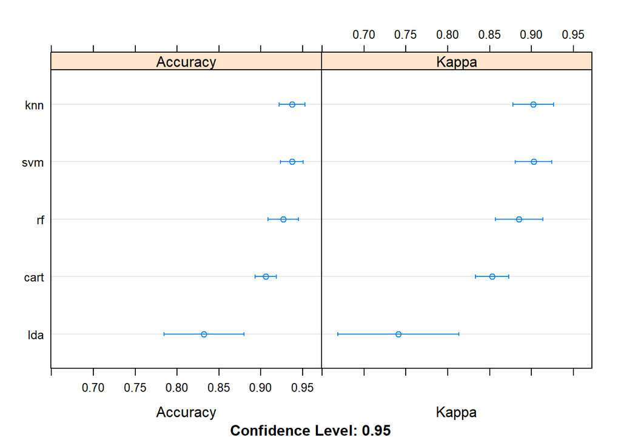

```r
# compare accuracy
dotplot(results)
```

```r
# summarize best model
print(fit.rf)
```

```
## Random Forest
##
## 670 samples
##   2 predictor
##   5 classes: 'astrocyte', 'excitatory_neuron', 'inhibitory_neuron', 'microglia', 'ODC_PDC'
##
## No pre-processing
## Resampling: Cross-Validated (10 fold)
## Summary of sample sizes: 603, 605, 605, 601, 603, 604, ...
## Resampling results:
##
##   Accuracy   Kappa
##   0.9266633  0.8851578
##
## Tuning parameter 'mtry' was held constant at a value of 2
```

### Validating the Best Model

```r
# validation of model
predictions.rf <- predict(fit.rf, validation)
confusionMatrix(predictions.rf, validation$type)
```

```
## Confusion Matrix and Statistics
##
##                    Reference
## Prediction          astrocyte excitatory_neuron inhibitory_neuron microglia
##   astrocyte                13                 0                 0         0
##   excitatory_neuron         0                82                 2         0
##   inhibitory_neuron         1                 3                46         0
##   microglia                 0                 0                 1         6
##   ODC_PDC                   0                 0                 0         0
##                    Reference
## Prediction          ODC_PDC
##   astrocyte               0
##   excitatory_neuron       0
##   inhibitory_neuron       1
##   microglia               0
##   ODC_PDC                11
##
## Overall Statistics
##
##                Accuracy : 0.9518
##                  95% CI : (0.9073, 0.979)
##     No Information Rate : 0.512
##     P-Value [Acc > NIR] : < 2.2e-16
##
##                   Kappa : 0.9244
##
##  Mcnemar's Test P-Value : NA
##
## Statistics by Class:
##
##                      Class: astrocyte Class: excitatory_neuron
## Sensitivity                   0.92857                   0.9647
## Specificity                   1.00000                   0.9753
## Pos Pred Value                1.00000                   0.9762
## Neg Pred Value                0.99346                   0.9634
## Prevalence                    0.08434                   0.5120
## Detection Rate                0.07831                   0.4940
## Detection Prevalence          0.07831                   0.5060
## Balanced Accuracy             0.96429                   0.9700
##                      Class: inhibitory_neuron Class: microglia Class: ODC_PDC
## Sensitivity                            0.9388          1.00000        0.91667
## Specificity                            0.9573          0.99375        1.00000
## Pos Pred Value                         0.9020          0.85714        1.00000
## Neg Pred Value                         0.9739          1.00000        0.99355
## Prevalence                             0.2952          0.03614        0.07229
## Detection Rate                         0.2771          0.03614        0.06627
## Detection Prevalence                   0.3072          0.04217        0.06627
## Balanced Accuracy                      0.9480          0.99687        0.95833
```

### Discussion

# Future Directions

The first analysis I would perform given more time would be to differential accessibility analysis between the clusters. Assuming that each cell type has a different pattern of accessible chromatin region, we could possibly correlate the pattern to the cell type based on our cluster identification (using the provided labels). This analysis will tell us which regions of the chromatin are likely being actively transcribe for each cell type. We should expect to see for astrocytes regions of the chromosome that contain markers for mature astrocytes, such as Aldh1L1, AldoC, and Glt1. If we see a region that is unique for astrocytes, we could perform knockout studies to understand the importance of those regions for astrocyte development and/or function.

Conversely, if already know what pattern there should be for a given cell type, we could use that information to identify the cluster and compare that with the provided labels. This might help us resolve why there is a group of excitatory neurons clustering together with the inhibitory neurons.

If we find the genes associated with the significantly differential regions between clusters, we could perform a GO and KEGG analysis. From this analysis, we would see the function of genes and pathways being upregulated or downregulated. Glial cells, for example, should have a higher expression of genes linked to myelin compared to neuronal cells. In particular, we can scan through these differentially accessible regions for motifs to which regulatory elements bind. Correlating this information with cell type would reveal whether there are cell-type specific regulatory elements.

Another possible analysis would be cell trajectory which predicts the direction of changes from one cell state to another. It would be interesting to see how glial cells or astrocyte differentiate from progenitor cells over pseudotime.